# Distribucion Gaussiana Multivariada

## Paquetes

### *Loading*

Cargamos los paquetes que usaremos en estas ilustraciones.

```r
if (require("mvtnorm") == FALSE){
  install.packages("mvtnorm")
}
if (require("MASS") == FALSE){
  install.packages("mvtnorm")
}
library("mvtnorm","MASS")
```

## Parte 1 - Teoria

## Definicion

### Caso Univariado (\(p=1\))

Iniciamos con la distribucion gaussiana unidimensional, acompanada por una funcion de densidad de probabilidad,

\[ f(x|\mu,\sigma^2) = (2\pi)^{-1/2} \sigma^{-1} \exp\left\{-(1/2\sigma^2) (x-\mu)^2\right\} \] con soporte en \(\Re\) para \(x\).

## Definicion

### Caso mulvivariado (\(p<\infty\))

El caso multivariado es una extension del univariado para \(\boldsymbol{x}=(x_1,\ldots,x_p)\), pero que toma en cuenta las interacciones entre las \(x_i\)s. Esta tiene una funcion de densidad conjunta dada por,

\[ f(\boldsymbol{x}|\boldsymbol{\mu},\boldsymbol{\Sigma}) = (2\pi)^{-p/2} \det(\boldsymbol{\Sigma})^{-1/2} \exp\left\{-\frac{1}{2} (\boldsymbol{x}-\boldsymbol{\mu})'\boldsymbol{\Sigma}^{-1}(\boldsymbol{x}-\boldsymbol{\mu})\right\}, \] con soporte en \(\Re^{p}\) para \(\boldsymbol{x}\).

- El espacio parametral para \((\boldsymbol{\mu},\boldsymbol{\Sigma})\) es \(\Re^p \times \mathcal{M}_p\), donde \(\mathcal{M}_p\) denota el espacio de todas las matrices de dimension \(p \times p\) positivo definidas y simetricas.
- Se denota como \(\boldsymbol{X} \sim N(\boldsymbol{x}|\boldsymbol{\mu},\boldsymbol{\Sigma})\).
- El numero de parametros "independientes" en \(\boldsymbol{\mu}\) es igual a \(p\), mientras que el numero de parametros independientes en \(\boldsymbol{\Sigma}\) es igual a \(p(p+1)/2\).

## Propiedades

### Propiedades basicas

Si \(\boldsymbol{X} \sim N(\boldsymbol{x}|\boldsymbol{\mu},\boldsymbol{\Sigma})\) entonces,

**P1.** Cualquier combinacion lineal de \(\boldsymbol{X}\) es gaussiana multivariada, i.e. para todo \(A\) matriz de dimension \(q\times p\) y \(c\) vector de dimension \(q \times 1\) se tiene que \[ \boldsymbol{Y}\sim N(\boldsymbol{y}|\boldsymbol{\mu}_y,\boldsymbol{\Sigma}_y), \] con soporte para \(\boldsymbol{y}\) en \(\Re^{q}\), tal que

\[ \boldsymbol{\mu}_y = A\boldsymbol{\mu} + c, \] y \[ \boldsymbol{\Sigma}_y = A\boldsymbol{\Sigma}A'. \]

## Propiedades

### Propiedades basicas

Si \(\boldsymbol{X} \sim N(\boldsymbol{x}|\boldsymbol{\mu},\boldsymbol{\Sigma})\) entonces,

**P2.** Cualquier subconjunto de \(\boldsymbol{X}\) tiene una distribucion gaussiana multivariada, i.e. si \(\boldsymbol{X}_{s}=(X_{s(1)},\ldots,X_{s(q)})\) (con \(q<p\)) es un subconjuno de \(\boldsymbol{X}\) para un subconjunto de indices \(\{s(1),\ldots,s(q)\}\) de \(\{1,\ldots,p\}\), entonces

\[ \boldsymbol{X}_{s} \sim N(\boldsymbol{x}_{s}|\boldsymbol{\mu}_{s} ,\boldsymbol{\Sigma}_{s}), \] donde \[ \boldsymbol{\mu}_s=(\mu_{s(1)},\ldots,\mu_{s(q)}), \] y \[ \boldsymbol{\Sigma}_s=\left(\sigma_{s(i)s(j)}\right)_{i,j=1}^{q}. \]

## Propiedades

### Propiedades basicas

Si \(\boldsymbol{X} \sim N(\boldsymbol{x}|\boldsymbol{\mu},\boldsymbol{\Sigma})\) entonces,

**P3.** Si un subconjunto de \(\boldsymbol{X}\) no esta correlacionado, entonces las variables de ese conjunto son *estocasticamente independientes*, i.e.

- Si \((X_i,X_j)\) son un subconjunto de \(\boldsymbol{X}\) (con \(i,j<p\)), tales que \[\sigma_{i,j}=0,\] entonces \(X_i\) y \(X_j\) son independientes estocasticamente con, \[ f(x_i,x_j|\mu_i,\mu_j,\sigma_{ii},\sigma_{jj},\sigma_{ij}) = N(x_i|\mu_i,\sigma_{ii})\times N(x_j|\mu_j,\sigma_{jj}). \]

## Propiedades

### Propiedades basicas

Si \(\boldsymbol{X} \sim N(\boldsymbol{x}|\boldsymbol{\mu},\boldsymbol{\Sigma})\) entonces,

**P4.** Si un \(A\) y \(B\) son dos matrices de dimension (\(q\times p\)) tales que \[ A\boldsymbol{\Sigma}B' = \boldsymbol{0}, \] de dimension \(q\times q\), entonces

- las variables \[ \boldsymbol{Y}_A = A\boldsymbol{X} \ \text{ y } \ \boldsymbol{Y}_B = B\boldsymbol{X}, \] son *estocasticamente independientes*.

## Condicionamiento

### Distribuciones condicionales

Supongamos que \(\boldsymbol{X}=(\boldsymbol{X}_1,\boldsymbol{X}_2)\), donde ambos componentes son de dimension \(p_1\) y \(p_2\) respectivamente (\(p=p_1+p_2\)).

- Lo anterior se conoce como una particion de dos componentes de \(\boldsymbol{X}\).
- Los parametros del modelo tambien estan particionados, i.e. \[ \boldsymbol{\mu} = (\boldsymbol{\mu}_1,\boldsymbol{\mu}_2). \]

\[ \boldsymbol{\Sigma} = \left( \begin{array}{cc} \boldsymbol{\Sigma}_{11} & \boldsymbol{\Sigma}_{12} \\ \boldsymbol{\Sigma}_{21} & \boldsymbol{\Sigma}_{22} \end{array} \right). \]

- La *distribucion marginal* de \(\boldsymbol{X}_i\) (\(i=1,2\) ) es \[ \boldsymbol{X}_i \sim N(\boldsymbol{x}_i|\boldsymbol{\mu}_i,\boldsymbol{\Sigma}_i). \]

## Condicionamiento

### Distribucion condicional \(\boldsymbol{X}_2|\boldsymbol{X}_1=\boldsymbol{x}_1\)

**P5.** La distribucion condicional de \(\boldsymbol{X}_2\) dado \(\boldsymbol{X}_1=\boldsymbol{x}_1\) es gaussiana multivariada, con \[ \boldsymbol{X}_2|\boldsymbol{X}_1=\boldsymbol{x}_1 \sim N\left(\boldsymbol{x}_2|\boldsymbol{\mu}_{2|1},\boldsymbol{\Sigma}_{2|1}\right), \] donde \[ \boldsymbol{\mu}_{2|1} = \boldsymbol{\mu}_2 + \boldsymbol{\Sigma}_{21}\boldsymbol{\Sigma}_{11}^{-1}(\boldsymbol{x}_1-\boldsymbol{\mu}_1), \] y \[ \boldsymbol{\Sigma}_{2|1} = \boldsymbol{\Sigma}_{22} - \boldsymbol{\Sigma}_{21}\boldsymbol{\Sigma}_{11}^{-1}\boldsymbol{\Sigma}_{12}. \]

- Esta propiedad es simetrica, en el sentido que la distribucion condicional de \(\boldsymbol{X}_1|\boldsymbol{X}_2=\boldsymbol{x}_2\) es analoga.

## Descomposicion

### Estructura espectral

**Definicion.-** Una matrix \(P\) de dimension \(p\times p\) es *ortogonal* si \(P P' = P' P=I\).

**TEOREMA:** Una matrix \(A\) simetrica de dimension \(p\times p\) puede reexpresarse como \[A=P \Lambda P',\] donde

- \(\Lambda = diag\{\lambda_1,\ldots,\lambda_p\}\) de *eigenvalores*
- \(P\) es una matriz ortogonal de eigenvectores columna.

**INTUICION**

- La matriz de *eigenvalores* representa *rotaciones* de coordenadas.
- La matriz de *eigenvalores* representan *contracciones* o *expansiones* de coordenadas.

## Descomposicion

### Acerca de determinantes

**PROPIEDAD.-** Bajo la descomposicion espectral de \(\boldsymbol{\Sigma}\) se sigue \[\det(\boldsymbol{\Sigma})=\prod_{j=1}^{p}\lambda_j.\]

**INTUICION**

- Los *eigenvalores* de \(\boldsymbol{\Sigma}\) nos indican el grado de variabilidad de cada dimension (por separado)
- Los \(\lambda_j\)s nos indican que tan expandida/contraida es la distribucion en esta dimension
- El factor \(\det(\boldsymbol{\Sigma})\) puede verse como un factor de expansion/contraccion de la distribucion gaussiana conjunta

## Visualizacion

### Contornos

La grafica de **contornos** nos permiten visualizar distribuciones gaussianas de dos dimensiones (i.e. es una representacion de graficas en 3D).

Los *contronos* se obtienen como *rebanadas* de la densidad conjunta en 2D.

Las lineas representan la coleccion de valores de \(\boldsymbol{x}\) que comparten el mismo nivel de \(N(\boldsymbol{x}|\mu,\Sigma)\).

**Propiedad.-** Los contornos se definen en terminos de \(\Lambda\) y \(P\) como **elipsoides** \[||\boldsymbol{\Sigma}^{-1/2}(\boldsymbol{x}-\boldsymbol{\mu})||=c^{2},\] siendo centradas en \(\boldsymbol{\mu}\) y con ejes en la direccion \(\sqrt{\lambda_j p_j}\).

## Visualizacion

### Contornos

Visualizacion de datos por contornos con **dependencia nula**.

```r
x.points <- seq(-3,3,length.out=100)
y.points <- x.points
z <- matrix(0,nrow=100,ncol=100)
mu <- c(0,0)
sigma <- matrix(c(2,0,0,1),nrow=2)
for(i in 1:100){
  for(j in 1:100){
    z[i,j] <- dmvnorm(c(x.points[i],y.points[j]),
                      mean=mu,sigma=sigma)
    }
}
png("contour_nula.png", 490, 490)
contour(x.points,y.points,z)
dev.off()
```

## Visualizacion

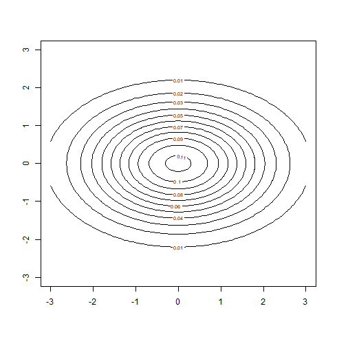

Contornos de distribucion gausiana.

## Visualizacion

### Contornos

Visualizacion de datos por contornos con **dependencia positiva.**

```r
x.points <- seq(-3,3,length.out=100)
y.points <- x.points
z <- matrix(0,nrow=100,ncol=100)
mu <- c(0,0)
sigma <- matrix(c(2,1,1,1),nrow=2)
for(i in 1:100){
  for(j in 1:100){
    z[i,j] <- dmvnorm(c(x.points[i],y.points[j]),
                      mean=mu,sigma=sigma)
    }
}
png("contour_positiva.png", 490, 490)
contour(x.points,y.points,z)
dev.off()
```

## Visualizacion

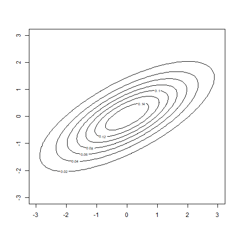

Contornos de distribucion gausiana con covarianza positiva

## Visualizacion

### Contornos

Visualizacion de datos por contornos con **dependencia negativa.**

```r
x.points <- seq(-3,3,length.out=100)
y.points <- x.points
z <- matrix(0,nrow=100,ncol=100)
mu <- c(0,0)
sigma <- matrix(c(2,-1,-1,1),nrow=2)
for(i in 1:100){
  for(j in 1:100){
    z[i,j] <- dmvnorm(c(x.points[i],y.points[j]),
                      mean=mu,sigma=sigma)
    }
}
png("contour_negativa.png", 490, 490)
contour(x.points,y.points,z)
dev.off()
```

## Visualizacion

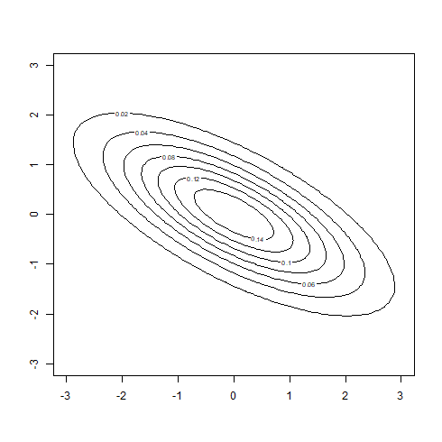

## Parte 2 - Practica

## Exploracion 1:1

```r
data01 <- read.csv(file="est46114_semana02.csv",header=TRUE)
summary(data01)
```

```
##        X1              X2
##  Min.   :340.0   Min.   :240.0
##  1st Qu.:470.0   1st Qu.:450.0
##  Median :500.0   Median :500.0
##  Mean   :499.3   Mean   :498.3
##  3rd Qu.:530.0   3rd Qu.:550.0
##  Max.   :640.0   Max.   :730.0
```

```r
X <- cbind(data01$X1,data01$X2)
```

## Visualizacion

### Nubes

Scatter plot (nube de datos eliptica)

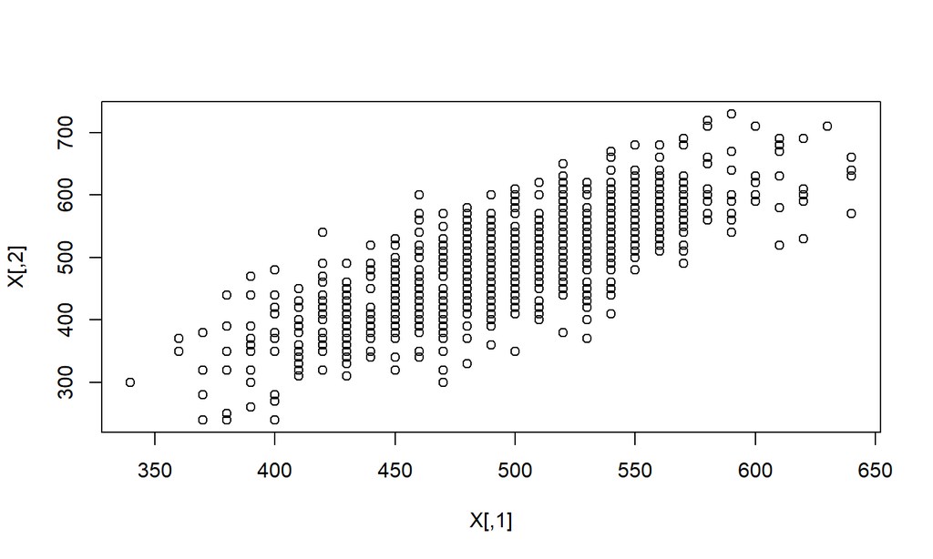

```r
plot(X)
```

## Verosimilitud

La funcion de verosimilitud para \((\mu,\Sigma)\) condicional en un conjunto de datos, \(\boldsymbol{x}_1,\ldots,\boldsymbol{x}_n\) se calcula como la distribucion conjunta de los \(n\) datos, la cual toma la forma \[ l(\mu,\Sigma|\boldsymbol{x}_1,\ldots,\boldsymbol{x}_n) = \prod_{i}N(\boldsymbol{x}_i|\mu,\Sigma) \\ \propto |\Sigma|^{-n/2}\exp\left\{-\frac{1}{2}\sum_{i}(x_i-\mu)'\Sigma^{-1}(x_i-\mu)\right\}\\ \propto |\Sigma|^{-n/2}\exp\left\{-\frac{1}{2}tr\left(\Sigma^{-1}(S+dd')\right)\right\}, \] donde \(d=\bar{x}-\mu\) y \(S\) es la matriz de covarianzas muestral.